# NGS Reads QC and Alignemnt

Beatriz Manso  
2022-03-24

# Introduction

Modern sequencing techniques enable researchers to sequence the genome at greater depth than ever before. NGS stands fro Next Generation Sequencing and allows for extremely high throughput, scalability, and speed. Using this technology, it is possible to determine nucleotide sequences within entire genomes or specific regions of DNA or RNA.

All high-throughput sequencing analyses require quality checks and processing of reads. Before we can quantify the genomic signal of interest and apply statistical and/or machine learning methods, we must process, quality check, and align the millions of reads generated by these sequencing experiments.

In this tutorial, we will assess the read quality and processing which are fundamental steps in all high-throughput sequencing analyses.

# Methods

## 1. Set working directory

```r
setwd("C:/Users/manso/OneDrive - University of West London/MSc Bioinformatics - UWL/6.BGA - Bioinformatics and Genome Analysis/week 2 - NGS data QC and alignment in R/practical")
```

## 2. Install necessary packages and load libraries

```r
if (!requireNamespace("BiocManager", quietly = TRUE))
   install.packages("BiocManager")
BiocManager::install("Rsubread")
BiocManager::install("ShortRead")
BiocManager::install("fastqcr")
BiocManager::install("Rqc")
BiocManager::install("QuasR")
BiocManager::install("ngsReports")
```

```r
library(fastqcr)
library(ShortRead)
library(ngsReports)
library(Rqc)
library(QuasR)
library(Rsubread)
```

## 3. Download Fasq data

We will use system.file() to upload data into a folder we will call ‘mydata’ in.

```r
mydata = system.file(package="ShortRead", "extdata/E-MTAB-1147")
```

Now feed *fastq.qz* files in “mydata” to the quality check function rqc() to create the object qcRes:

```r
qcRes=rqc(path = mydata, pattern = ".fastq.gz", openBrowser=FALSE)
```

Report is in C:/Users/manso/AppData/Local/Temp/RtmpMbKuwN/rqc_report.html Pasting the file path in browser window will show the html report.

## 4. Plot quality metrics

Plot a sequence quality per base/cycle metrics for our fastq files in qcRes object use

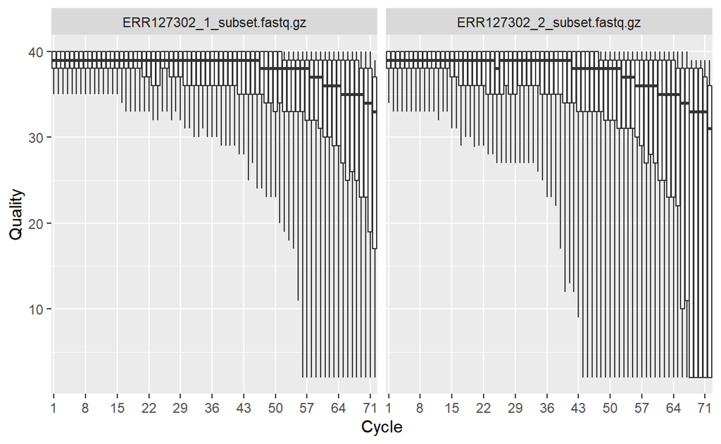

```r
rqcCycleQualityBoxPlot(qcRes)
```

**What does this graph depicts?**

The graph above shows the sequence quality per base/cycle metrics, we can observe that the quality of the reads degrades at the end which is expected for long sequences. Good samples will have median quality scores per base above 28. If scores are below 20 towards the ends, you can think about trimming the reads.

**Why is the x-axis labelled as ‘cycle’?**

Cycles correspond to bases/nucleotides along the read, and the number of cycles is equivalent to the read length.

## 5. Find Sequence content per base/cycle

```r
rqcCycleBaseCallsLinePlot(qcRes)
```

[output not shown]

**What does the per base sequence content show?**

Per-base sequence content shows nucleotide proportions for each position.

**This plot shows sequence bias – what is the probable cause of the bias?**

Some types of sequencing libraries can produce a biased sequence composition. For example, in RNA-Seq, it is common to have bias at the beginning of the reads. This happens because of random primers annealing to the start of reads during RNA-Seq library preparation. These primers are not truly random, which leads to a variation at the beginning of the reads. Although RNA-seq experiments will usually have these biases, this will not affect the ability of measuring gene expression.

## 6. Filtering and trimming read

It might be necessary to trim or filter the reads based on the quality check results. It may be that adapters are present on either side of the read, or that technical errors are causing the base quality to diminish toward the ends of the read. This portion of the read should be trimmed, in both cases, to allow alignment or better alignment of the genome.

We can use QuasR or ShortRead packages to trim and filter reads the reads. However, QuasR::preprocessReads() function provides a single interface to multiple pre-processing.

### 6.1. First, Obtain a list of fastq file paths:

```r
fastqFiles <- system.file(package="ShortRead",
                          "extdata/E-MTAB-1147",
                          c("ERR127302_1_subset.fastq.gz", "ERR127302_2_subset.fastq.gz"))
```

For this tutorial we are using built in training data from the package - and we access this data using ‘system.file’ command. When using our own data we must create the correct filepath for our data.

### 6.2. Next, Define processed fastq file names:

```r
outfiles <- paste(tempfile(pattern=c("processed_1_", "processed_2_")),".fastq",sep="")
```

### 6.3. Then we Process fastq files with the following parameters as an example:

1. Remove reads that have more than 1 N, (nBases)
2. trim 3 bases from the end of the reads (truncateEndBases)
3. remove ACCCGGGA patern if it occurs at the start (Lpattern)
4. remove reads shorter than 40 base-pairs (minLength)

```r
preprocessReads(fastqFiles, outfiles, nBases=1,
                truncateEndBases=3,Lpattern="ACCCGGGA",
                minLength=40)
```

```
                 ERR127302_1_subset.fastq.gz
totalSequences                         20000
matchTo5pAdapter                        3804
matchTo3pAdapter                           0
tooShort                                 355
tooManyN                                   4
lowComplexity                              0
totalPassed                            19641
                 ERR127302_2_subset.fastq.gz
totalSequences                         20000
matchTo5pAdapter                        3398
matchTo3pAdapter                           0
tooShort                                 426
tooManyN                                   1
lowComplexity                              0
totalPassed                            19573
```

### 6.4. Filter out reads with quality score below 20:

- Obtain a list of fastq file paths:

```r
fastqFile <- system.file(package="ShortRead",
                         "extdata/E-MTAB-1147",
                         "ERR127302_1_subset.fastq.gz")
```

- Read fastq file:

```r
fq = readFastq(fastqFile)
```

- Get quality scores per base as a matrix:

```r
qPerBase = as(quality(fq), "matrix")
```

- Get the number of bases per read that have quality score below 20:

```r
qcount = rowSums( qPerBase <= 20)
```

- Number of reads where all Phred scores >= 20

```r
fq[qcount == 0]
```

```
class: ShortReadQ
length: 10699 reads; width: 72 cycles
```

- Write out fastq file with only reads where all quality scores per base are above 20:

```r
writeFastq(fq[qcount == 0], paste(fastqFile, "Qfiltered", sep="_"))
```

ShortRead::FastqStreamer() - streams the fastq file in blocks, each with a pre-defined number of reads. Which can be accessed using the yield() function. As we call the yield() function after opening a fastq file with FastqStreamer(), a new section of the file is read into memory.

- Set up a streaming with block size 1000. Every time you call the yield() function 1000 read portion of the file will be read successively.

```r
f <- FastqStreamer(fastqFile, readerBlockSize=1000)
```

- Set up a while loop to call yield() function to go through the file:

```r
while(length(fq <- yield(f))) {
  qPerBase = as(quality(fq), "matrix")
  qcount = rowSums( qPerBase <= 20)
  writeFastq(fq[qcount == 0],
             paste(fastqFile, "Qfiltered", sep="_"),
             mode="a")
}
```

## 7. Map or align the reads to the genome (library(QuasR) is needed)

### 7.1. Copy example data to current working directory:

```r
file.copy(system.file(package="QuasR", "extdata"), ".", recursive=TRUE)
```

```
[1] TRUE
```

### 7.2. Get genome file in fasta format:

```r
genomeFile <- "extdata/hg19sub.fa"
```

### 7.3. Get text file containing sample names and fastq file paths:

```r
sampleFile <- "extdata/samples_chip_single.txt"
```

### 7.4. Create alignments:

```r
proj <- qAlign(sampleFile, genomeFile)
```

With qAlign(), alignment parameters are automatically selected based on different types of alignment problems

## 8. Map or align the reads to the genome with Rsubread

Data files needed:

- Mouse chromosome
- 1 Rsubread index files (~400MB);
- Targets2.txt
- The 12 fastq.gz files for the mouse dataset: 12 fastq files with 1000 reads each
- 4 index files for chr 1 for mm10, targets files with sample information.
1. Put all the sequencing read data (.fastq.gz files) in your data directory.
2. Find the files and command Rsubread aligner which files to look at.

### 8.1. Search for all .fastq.gz files in the directory using the list.files command.

```r
fastq.files <- list.files(path = "C:/Users/manso/OneDrive - University of West London/MSc Bioinformatics - UWL/6.BGA - Bioinformatics and Genome Analysis/week 2 - NGS data QC and alignment in R/practical/MouseMamRNA-Seq", pattern = ".fastq.gz$", full.names = TRUE)

fastq.files
```

```
 [1] "C:/Users/manso/OneDrive - University of West London/MSc Bioinformatics - UWL/6.BGA - Bioinformatics and Genome Analysis/week 2 - NGS data QC and alignment in R/practical/MouseMamRNA-Seq/SRR1552444.fastq.gz"
 [2] "C:/Users/manso/OneDrive - University of West London/MSc Bioinformatics - UWL/6.BGA - Bioinformatics and Genome Analysis/week 2 - NGS data QC and alignment in R/practical/MouseMamRNA-Seq/SRR1552445.fastq.gz"
 [3] "C:/Users/manso/OneDrive - University of West London/MSc Bioinformatics - UWL/6.BGA - Bioinformatics and Genome Analysis/week 2 - NGS data QC and alignment in R/practical/MouseMamRNA-Seq/SRR1552446.fastq.gz"
 [4] "C:/Users/manso/OneDrive - University of West London/MSc Bioinformatics - UWL/6.BGA - Bioinformatics and Genome Analysis/week 2 - NGS data QC and alignment in R/practical/MouseMamRNA-Seq/SRR1552447.fastq.gz"
 [5] "C:/Users/manso/OneDrive - University of West London/MSc Bioinformatics - UWL/6.BGA - Bioinformatics and Genome Analysis/week 2 - NGS data QC and alignment in R/practical/MouseMamRNA-Seq/SRR1552448.fastq.gz"
 [6] "C:/Users/manso/OneDrive - University of West London/MSc Bioinformatics - UWL/6.BGA - Bioinformatics and Genome Analysis/week 2 - NGS data QC and alignment in R/practical/MouseMamRNA-Seq/SRR1552449.fastq.gz"
 [7] "C:/Users/manso/OneDrive - University of West London/MSc Bioinformatics - UWL/6.BGA - Bioinformatics and Genome Analysis/week 2 - NGS data QC and alignment in R/practical/MouseMamRNA-Seq/SRR1552450.fastq.gz"
 [8] "C:/Users/manso/OneDrive - University of West London/MSc Bioinformatics - UWL/6.BGA - Bioinformatics and Genome Analysis/week 2 - NGS data QC and alignment in R/practical/MouseMamRNA-Seq/SRR1552451.fastq.gz"
 [9] "C:/Users/manso/OneDrive - University of West London/MSc Bioinformatics - UWL/6.BGA - Bioinformatics and Genome Analysis/week 2 - NGS data QC and alignment in R/practical/MouseMamRNA-Seq/SRR1552452.fastq.gz"
[10] "C:/Users/manso/OneDrive - University of West London/MSc Bioinformatics - UWL/6.BGA - Bioinformatics and Genome Analysis/week 2 - NGS data QC and alignment in R/practical/MouseMamRNA-Seq/SRR1552453.fastq.gz"
[11] "C:/Users/manso/OneDrive - University of West London/MSc Bioinformatics - UWL/6.BGA - Bioinformatics and Genome Analysis/week 2 - NGS data QC and alignment in R/practical/MouseMamRNA-Seq/SRR1552454.fastq.gz"
[12] "C:/Users/manso/OneDrive - University of West London/MSc Bioinformatics - UWL/6.BGA - Bioinformatics and Genome Analysis/week 2 - NGS data QC and alignment in R/practical/MouseMamRNA-Seq/SRR1552455.fastq.gz"
```

The pattern argument takes a regular expression. In this case, we are using the “$” to mean the end of the string, so we will only get files that end in “.fastq.gz”

### 8.2. Build the Index:

```r
#buildindex(basename="./reference_index",reference=ref)
buildindex(basename="chr1_mm10",reference="chr1.fa")
```

[output not shown]

[output cut: 17 more lines]

```
||  [ 10.0% finished ]                                                        ||
||  [ 20.0% finished ]                                                        ||
||  [ 30.0% finished ]                                                        ||
||  [ 40.0% finished ]                                                        ||
||  [ 50.0% finished ]                                                        ||
||  [ 60.0% finished ]                                                        ||
||  [ 70.0% finished ]                                                        ||
||  [ 80.0% finished ]                                                        ||
||  [ 90.0% finished ]                                                        ||
||  [ 100.0% finished ]                                                       ||
||                                                                            ||
||                      Total running time: 3.0 minutes.                      ||
||Index C:\Users\manso\OneDrive - University of West London\MSc Bioinfor ... ||
||                                                                            ||
\\============================================================================//
```

With our index generated, we can align the reads with the align command.

### 8.3. Align the reads using the align command:

```r
#to view and change parameters run: args(align)

align("chr1_mm10", readfile1 = fastq.files,
      useAnnotation=T, nthreads=10, annot.inbuilt="mm10",
      phredOffset = 64 )
```

[output not shown]

[output cut: 1324 more lines]

```
||                                                                            ||
||                 Total reads : 1000                                         ||
||                      Mapped : 117 (11.7%)                                  ||
||             Uniquely mapped : 112                                          ||
||               Multi-mapping : 5                                            ||
||                                                                            ||
||                    Unmapped : 883                                          ||
||                                                                            ||
||                      Indels : 6                                            ||
||                                                                            ||
||                     WARNING : Phred offset (64) incorrect?                 ||
||                                                                            ||
||                Running time : 0.4 minutes                                  ||
||                                                                            ||
\\============================================================================//
```

```
                      SRR1552444.fastq.gz.subread.BAM
Total_reads                                      1000
Mapped_reads                                      141
Uniquely_mapped_reads                             129
Multi_mapping_reads                                12
Unmapped_reads                                    859
Indels                                              9
                      SRR1552445.fastq.gz.subread.BAM
Total_reads                                      1000
Mapped_reads                                      132
Uniquely_mapped_reads                             127
Multi_mapping_reads                                 5
Unmapped_reads                                    868
Indels                                              1
                      SRR1552446.fastq.gz.subread.BAM
Total_reads                                      1000
Mapped_reads                                      119
Uniquely_mapped_reads                             111
Multi_mapping_reads                                 8
Unmapped_reads                                    881
Indels                                              7
                      SRR1552447.fastq.gz.subread.BAM
Total_reads                                      1000
Mapped_reads                                      112
Uniquely_mapped_reads                             104
Multi_mapping_reads                                 8
Unmapped_reads                                    888
Indels                                              3
                      SRR1552448.fastq.gz.subread.BAM
Total_reads                                      1000
Mapped_reads                                       53
Uniquely_mapped_reads                              51
Multi_mapping_reads                                 2
Unmapped_reads                                    947
Indels                                              1
                      SRR1552449.fastq.gz.subread.BAM
Total_reads                                      1000
Mapped_reads                                       75
Uniquely_mapped_reads                              66
Multi_mapping_reads                                 9
```

[output cut: 29 more lines]

```
Indels                                              5
                      SRR1552454.fastq.gz.subread.BAM
Total_reads                                      1000
Mapped_reads                                      130
Uniquely_mapped_reads                             126
Multi_mapping_reads                                 4
Unmapped_reads                                    870
Indels                                              2
                      SRR1552455.fastq.gz.subread.BAM
Total_reads                                      1000
Mapped_reads                                      117
Uniquely_mapped_reads                             112
Multi_mapping_reads                                 5
Unmapped_reads                                    883
Indels                                              6
```

If we have paired end data, we would need to specify the second read file/s using the readfile2 argument. The mouse data for this experiment are 100bp single end reads.(this might take very long time to complete)

We can specify the output files, or we can let Rsubread choose the output file names for us. The default output file name is the filename with “.subread.BAM” added at the end.

### 8.4. Get a summary of the proportion of reads that mapped to the reference genome using the `propmapped` function:

```r
bam.files <- list.files(path = "C:/Users/manso/OneDrive - University of West London/MSc Bioinformatics - UWL/6.BGA - Bioinformatics and Genome Analysis/week 2 - NGS data QC and alignment in R/practical/MouseMamRNA-Seq", pattern = ".BAM$", full.names = TRUE)

bam.files
```

```
 [1] "C:/Users/manso/OneDrive - University of West London/MSc Bioinformatics - UWL/6.BGA - Bioinformatics and Genome Analysis/week 2 - NGS data QC and alignment in R/practical/MouseMamRNA-Seq/SRR1552444.fastq.gz.subread.BAM"
 [2] "C:/Users/manso/OneDrive - University of West London/MSc Bioinformatics - UWL/6.BGA - Bioinformatics and Genome Analysis/week 2 - NGS data QC and alignment in R/practical/MouseMamRNA-Seq/SRR1552445.fastq.gz.subread.BAM"
 [3] "C:/Users/manso/OneDrive - University of West London/MSc Bioinformatics - UWL/6.BGA - Bioinformatics and Genome Analysis/week 2 - NGS data QC and alignment in R/practical/MouseMamRNA-Seq/SRR1552446.fastq.gz.subread.BAM"
 [4] "C:/Users/manso/OneDrive - University of West London/MSc Bioinformatics - UWL/6.BGA - Bioinformatics and Genome Analysis/week 2 - NGS data QC and alignment in R/practical/MouseMamRNA-Seq/SRR1552447.fastq.gz.subread.BAM"
 [5] "C:/Users/manso/OneDrive - University of West London/MSc Bioinformatics - UWL/6.BGA - Bioinformatics and Genome Analysis/week 2 - NGS data QC and alignment in R/practical/MouseMamRNA-Seq/SRR1552448.fastq.gz.subread.BAM"
 [6] "C:/Users/manso/OneDrive - University of West London/MSc Bioinformatics - UWL/6.BGA - Bioinformatics and Genome Analysis/week 2 - NGS data QC and alignment in R/practical/MouseMamRNA-Seq/SRR1552449.fastq.gz.subread.BAM"
 [7] "C:/Users/manso/OneDrive - University of West London/MSc Bioinformatics - UWL/6.BGA - Bioinformatics and Genome Analysis/week 2 - NGS data QC and alignment in R/practical/MouseMamRNA-Seq/SRR1552450.fastq.gz.subread.BAM"
 [8] "C:/Users/manso/OneDrive - University of West London/MSc Bioinformatics - UWL/6.BGA - Bioinformatics and Genome Analysis/week 2 - NGS data QC and alignment in R/practical/MouseMamRNA-Seq/SRR1552451.fastq.gz.subread.BAM"
 [9] "C:/Users/manso/OneDrive - University of West London/MSc Bioinformatics - UWL/6.BGA - Bioinformatics and Genome Analysis/week 2 - NGS data QC and alignment in R/practical/MouseMamRNA-Seq/SRR1552452.fastq.gz.subread.BAM"
[10] "C:/Users/manso/OneDrive - University of West London/MSc Bioinformatics - UWL/6.BGA - Bioinformatics and Genome Analysis/week 2 - NGS data QC and alignment in R/practical/MouseMamRNA-Seq/SRR1552453.fastq.gz.subread.BAM"
[11] "C:/Users/manso/OneDrive - University of West London/MSc Bioinformatics - UWL/6.BGA - Bioinformatics and Genome Analysis/week 2 - NGS data QC and alignment in R/practical/MouseMamRNA-Seq/SRR1552454.fastq.gz.subread.BAM"
[12] "C:/Users/manso/OneDrive - University of West London/MSc Bioinformatics - UWL/6.BGA - Bioinformatics and Genome Analysis/week 2 - NGS data QC and alignment in R/practical/MouseMamRNA-Seq/SRR1552455.fastq.gz.subread.BAM"
```

```r
props <- propmapped(files=bam.files)
props
```

```
                                NumTotal NumMapped PropMapped
SRR1552444.fastq.gz.subread.BAM     1000       141      0.141
SRR1552445.fastq.gz.subread.BAM     1000       132      0.132
SRR1552446.fastq.gz.subread.BAM     1000       119      0.119
SRR1552447.fastq.gz.subread.BAM     1000       112      0.112
SRR1552448.fastq.gz.subread.BAM     1000        53      0.053
SRR1552449.fastq.gz.subread.BAM     1000        75      0.075
SRR1552450.fastq.gz.subread.BAM     1000       124      0.124
SRR1552451.fastq.gz.subread.BAM     1000       158      0.158
SRR1552452.fastq.gz.subread.BAM     1000       142      0.142
SRR1552453.fastq.gz.subread.BAM     1000       147      0.147
SRR1552454.fastq.gz.subread.BAM     1000       130      0.130
SRR1552455.fastq.gz.subread.BAM     1000       117      0.117
```

As a result of the alignment, there are several BAM files, each containing read alignments for each library. BAM files contain the chromosomal location of each read.

## 9. Quality control after alignemnt

By using the qualityScores function in Rsubread, we can examine the quality scores associated with each base that has been called by the sequencing machine.

### 9.1. Extract quality scores(qs) for 100 reads

```r
qs <- qualityScores(filename="C:/Users/manso/OneDrive - University of West London/MSc Bioinformatics - UWL/6.BGA - Bioinformatics and Genome Analysis/week 2 - NGS data QC and alignment in R/practical/MouseMamRNA-Seq/SRR1552450.fastq.gz",nreads=100)
```

```
qualityScores Rsubread 2.8.2

Scan the input file...
Totally 1000 reads were scanned; the sampling interval is 9.
Now extract read quality information...

Completed successfully. Quality scores for 100 reads (equally spaced in the file) are returned.
```

### 9.2. Check dimension of qs

```r
dim(qs)
```

```
[1] 100 100
```

### 9.3. Check first few elements of qs with head:

```r
head(qs)
```

```
      1  2  3  4  5  6  7  8  9 10 11 12 13 14 15 16 17 18 19 20 21
[1,] 31 34 31 37 37 37 37 37 39 37 39 39 39 41 40 41 41 41 36 38 40
[2,] 34 34 34 37 37 37 37 37 39 39 39 39 39 41 41 41 41 39 40 41 41
[3,] 34 34 31 37 37 37 37 37 39 39 39 39 39 41 41 41 41 41 41 41 41
[4,] 34 34 34 37 37 37 37 37 39 39 39 39 39 41 41 41 41 39 40 40 41
[5,] 34 34 34 37 37 37 37 37 39 39 39 39 39 41 41 41 40 41 41 41 41
[6,] 34 34 34 37 37 37 37 37 39 39 39 39 39 41 41 41 41 41 41 41 41
     22 23 24 25 26 27 28 29 30 31 32 33 34 35 36 37 38 39 40 41 42
[1,] 41 39 40 38 40 40 40 40 40 38 40 40 40 38 37 39 40 40 41 40 41
[2,] 41 41 41 41 41 41 41 41 41 41 41 38 40 41 41 41 41 41 41 41 41
[3,] 41 41 41 41 41 41 41 41 40 40 41 38 38 38 40 41 40 41 39 40 40
[4,] 41 41 41 40 41 41 41 41 41 40 41 41 41 41 40 41 41 41 41 41 41
[5,] 41 41 40 41 41 41 41 41 39 40 41 41 41 41 40 41 41 41 41 41 41
[6,] 41 41 41 41 36 40 40 41 41 41 41 40 38 40 38 40 41 41 40 41 41
     43 44 45 46 47 48 49 50 51 52 53 54 55 56 57 58 59 60 61 62 63
```

[output cut: 20 more lines]

### 9.4. Visualise Quality scores

With a quality score of 30, the likelihood of making an incorrect call is 1 in 1000. (A quality score of 10 is a 1 in 10 chance of an incorrect base call.) A boxplot can be used to examine the overall distribution of quality scores across the 100 reads.

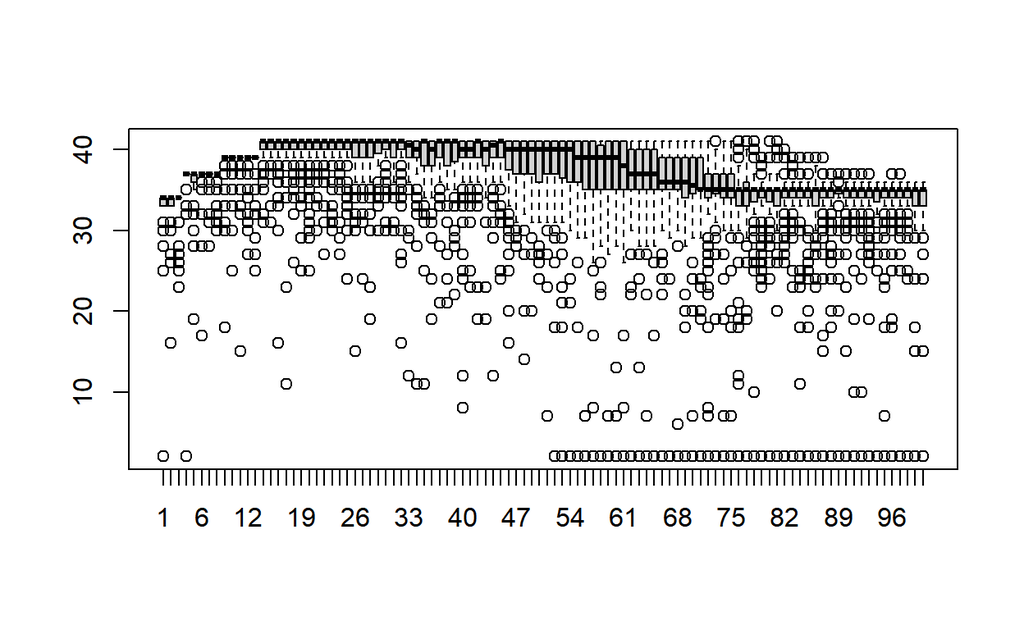

```r
boxplot(qs)
```

## 10. Counting

The featureCounts() function can be used to calculate the number of mapped reads across mouse genes. There are built-in annotations for mouse genome assemblies (mm9, mm10) and human genome assemblies (hg19) (NCBI refseq annotations).

featureCounts() takes all the BAM files as input, and outputs an object which includes the count matrix. Each sample is a separate column, each row is a gene.

```r
fc <- featureCounts(bam.files, annot.inbuilt="mm10")
```

[output not shown]

[output cut: 67 more lines]

```
||    Single-end reads are included.                                          ||
||    Total alignments : 1000                                                 ||
||    Successfully assigned alignments : 1 (0.1%)                             ||
||    Running time : 0.00 minutes                                             ||
||                                                                            ||
|| Process BAM file SRR1552455.fastq.gz.subread.BAM...                        ||
||    Single-end reads are included.                                          ||
||    Total alignments : 1000                                                 ||
||    Successfully assigned alignments : 5 (0.5%)                             ||
||    Running time : 0.00 minutes                                             ||
||                                                                            ||
|| Write the final count table.                                               ||
|| Write the read assignment summary.                                         ||
||                                                                            ||
\\============================================================================//
```

```r
names(fc) #See what slots are stored in fc
```

```
[1] "counts"     "annotation" "targets"    "stat"
```

“fc$stat” shows the statistics of the read mapping, also reporting the unassigned reads and the reasons why they weren’t assigned:

```r
fc$stat
```

```
                          Status SRR1552444.fastq.gz.subread.BAM
1                       Assigned                               2
2            Unassigned_Unmapped                             859
3           Unassigned_Read_Type                               0
4           Unassigned_Singleton                               0
5      Unassigned_MappingQuality                               0
6             Unassigned_Chimera                               0
7      Unassigned_FragmentLength                               0
8           Unassigned_Duplicate                               0
9        Unassigned_MultiMapping                               0
10          Unassigned_Secondary                               0
11           Unassigned_NonSplit                               0
12         Unassigned_NoFeatures                             138
13 Unassigned_Overlapping_Length                               0
14          Unassigned_Ambiguity                               1
```

[output cut: 90 more lines]

FeatureCounts() compiled reads over genes using annotation information in the annotation slot.

```r
head(fc$annotation)
```

```
     GeneID                           Chr
1    497097                chr1;chr1;chr1
2 100503874                     chr1;chr1
3 100038431                          chr1
4     19888 chr1;chr1;chr1;chr1;chr1;chr1
5     20671      chr1;chr1;chr1;chr1;chr1
6     27395      chr1;chr1;chr1;chr1;chr1
                                            Start
1                         3214482;3421702;3670552
2                                 3647309;3658847
3                                         3680155
4 4290846;4343507;4351910;4352202;4360200;4409170
5         4490928;4493100;4493772;4495136;4496291
6         4773198;4777525;4782568;4783951;4785573
                                              End      Strand Length
1                         3216968;3421901;3671498       -;-;-   3634
2                                 3650509;3658904         -;-   3259
3                                         3681788           +   1634
4 4293012;4350091;4352081;4352837;4360314;4409241 -;-;-;-;-;-   9747
5         4492668;4493466;4493863;4495942;4496413   -;-;-;-;-   3130
6         4776801;4777648;4782733;4784105;4785726   -;-;-;-;-   4203
```